# Tarea 1: caja de herramientas de pronóstico

# 8 Ejemplo 7. Tendencia exponencial sobre `JohnsonJohnson`

```r
jj <- leer_serie(JohnsonJohnson,
  fuente = "R datasets: JohnsonJohnson. Shumway y Stoffer (2000), utilidades trimestrales por acción, 1960-1980",
  unidad = "Utilidad por acción (dólares)")
knitr::kable(describir_serie(jj, "JohnsonJohnson"), digits = 3)
```

| serie | fuente | unidad | frecuencia | inicio | fin | observaciones | media | desv_estandar | minimo | maximo |
| --- | --- | --- | --- | --- | --- | --- | --- | --- | --- | --- |
| JohnsonJohnson | R datasets: JohnsonJohnson. Shumway y Stoffer (2000), utilidades trimestrales por acción, 1960-1980 | Utilidad por acción (dólares) | 4 | 1960-01-01 | 1980-10-01 | 84 | 4.8 | 4.31 | 0.44 | 16.2 |

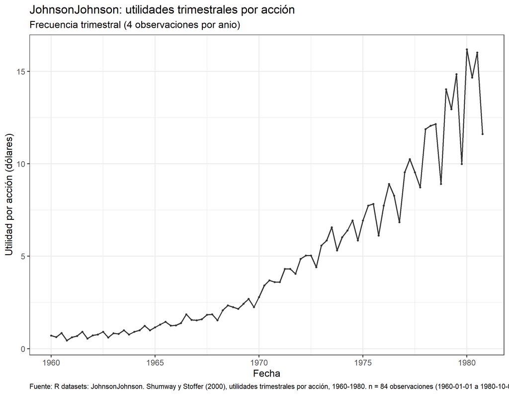

```r
graficar_serie(jj, "JohnsonJohnson: utilidades trimestrales por acción")
```

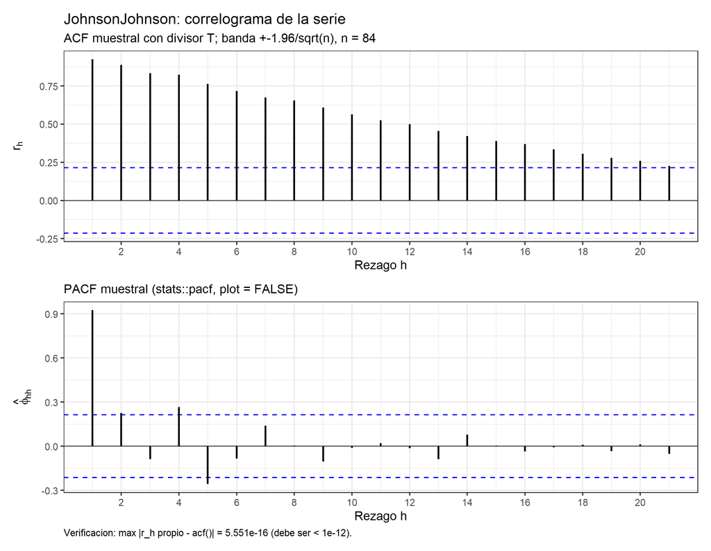

```r
correlograma(jj, titulo = "JohnsonJohnson: correlograma de la serie")
```

```r
ej7 <- protocolo_ejemplo(jj, "JohnsonJohnson",
  function(y) ajustar_tendencia(y, "exponencial", corregir_sesgo = TRUE),
  "tendencia exponencial", p = 2, estacional = TRUE, imprimir = FALSE)
par7 <- ej7$ajuste$parametros
knitr::kable(par7$tabla_coeficientes, digits = 5)
```

| coeficiente | estimacion | ee_ordinario | t_ordinario | p_ordinario | ee_hac | t_hac | p_hac |
| --- | --- | --- | --- | --- | --- | --- | --- |
| a | -0.69684 | 0.03597 | -19.37372 | 0 | 0.04258 | -16.36631 | 0 |
| theta | 0.04277 | 0.00086 | 49.94309 | 0 | 0.00100 | 42.96160 | 0 |

```r
c(b0 = par7$b0_exponencial, b1 = par7$b1_exponencial,
  factor_sesgo = par7$factor_sesgo, R2_log = par7$R2, DW = par7$durbin_watson)
```

```
        b0.a     b1.theta factor_sesgo       R2_log           DW
   0.4981558    1.0436966    1.0114679    0.9727022    1.6898392
```

```r
for (j in seq_len(nrow(par7$tabla_coeficientes))) {
  tc <- par7$tabla_coeficientes[j, ]
  invisible(reportar_prueba(t_coeficiente(tc$estimacion, tc$ee_hac, par7$gl, tc$coeficiente)))
}
```

```
--- t sobre a (EE robusto HAC) ---
1. H0: a = 0
   H1: a != 0
2. Estadistico: t = a_hat / EE_HAC(a_hat) ~ t_{T-k}  (gl = 70)
3. Region de rechazo al 5 %: se rechaza H0 si |t| > t_{0.975, 70} = 1.9944
4. Valor observado = -16.366310 ; valor p = 1.258e-25
5. Decision: se rechaza H0 al 5 %
6. Lectura: Se rechaza H0: el coeficiente a es significativamente distinto de cero (con error estandar robusto HAC).

--- t sobre theta (EE robusto HAC) ---
1. H0: theta = 0
   H1: theta != 0
2. Estadistico: t = theta_hat / EE_HAC(theta_hat) ~ t_{T-k}  (gl = 70)
3. Region de rechazo al 5 %: se rechaza H0 si |t| > t_{0.975, 70} = 1.9944
4. Valor observado = 42.961603 ; valor p = 4.816e-52
5. Decision: se rechaza H0 al 5 %
6. Lectura: Se rechaza H0: el coeficiente theta es significativamente distinto de cero (con error estandar robusto HAC).
```

```r
knitr::kable(dplyr::bind_rows(
  dplyr::mutate(ej7$medidas_dentro, tramo = "estimación"),
  dplyr::mutate(ej7$medidas_fuera,  tramo = "validación"),
  dplyr::mutate(ej7$medidas_referente, tramo = "ingenuo estacional")), digits = 3)
```

| n | MSE | RMSE | MAD | MAPE | MASE | tramo |
| --- | --- | --- | --- | --- | --- | --- |
| 72 | 0.332 | 0.576 | 0.363 | 12.073 | 0.691 | estimación |
| 12 | 8.329 | 2.886 | 1.883 | 16.919 | 3.586 | validación |
| 12 | 15.581 | 3.947 | 3.428 | 24.651 | 6.529 | ingenuo estacional |

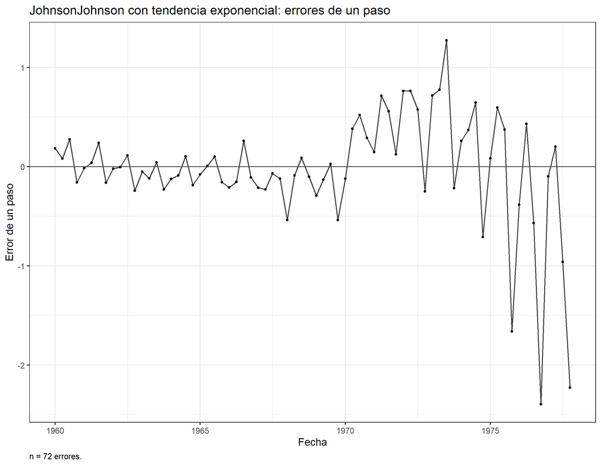

```r
ej7$validacion$grafico_errores
```

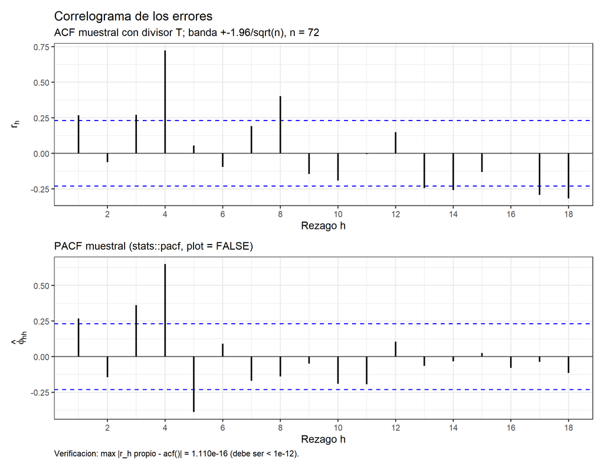

```r
ej7$validacion$correlograma
```

```r
reportar_validacion(ej7)
```

```
=== Prueba sobre la serie JohnsonJohnson ===
--- Ljung-Box ---
1. H0: rho_1 = ... = rho_m = 0 (los errores/observaciones no estan autocorrelacionados)
   H1: algun rho_h distinto de cero para h = 1,...,m
2. Estadistico: Q_m = T(T+2) sum_{h=1}^{m} r_h^2/(T-h) ~ chi^2_{m-p}  (gl = 21)
3. Region de rechazo al 5 %: se rechaza H0 si Q_m > chi^2_{0.95, 21} = 32.6706
4. Valor observado = 685.350704 ; valor p = 1.649e-131
5. Decision: se rechaza H0 al 5 %
6. Lectura: Se rechaza H0: hay autocorrelacion (estructura temporal) en la serie JohnsonJohnson.

=== Pruebas sobre los errores de un paso: JohnsonJohnson con tendencia exponencial ===
--- t de media cero ---
1. H0: mu_e = 0 (el metodo no esta sesgado)
   H1: mu_e != 0 (el metodo esta sesgado)
2. Estadistico: t = ebar / (s_e/sqrt(n)) ~ t_{n-1}  (gl = 71)
3. Region de rechazo al 5 %: se rechaza H0 si |t| > t_{0.975, 71} = 1.9939
4. Valor observado = -0.369694 ; valor p = 0.7127
5. Decision: no se rechaza H0 al 5 %
6. Lectura: No se rechaza H0: no hay evidencia de sesgo sistematico en los errores de un paso de JohnsonJohnson con tendencia exponencial.

--- Ljung-Box ---
1. H0: rho_1 = ... = rho_m = 0 (los errores/observaciones no estan autocorrelacionados)
   H1: algun rho_h distinto de cero para h = 1,...,m
2. Estadistico: Q_m = T(T+2) sum_{h=1}^{m} r_h^2/(T-h) ~ chi^2_{m-p}  (gl = 16)
3. Region de rechazo al 5 %: se rechaza H0 si Q_m > chi^2_{0.95, 16} = 26.2962
4. Valor observado = 108.202446 ; valor p = 9.841e-16
5. Decision: se rechaza H0 al 5 %
6. Lectura: Se rechaza H0: hay autocorrelacion (estructura temporal) en los errores de un paso de JohnsonJohnson con tendencia exponencial.

--- Jarque-Bera ---
1. H0: los errores provienen de una distribucion normal (A = 0 y K = 3)
   H1: los errores no son normales (A != 0 o K != 3)
2. Estadistico: JB = (N/6)(A^2 + (K-3)^2/4) ~ chi^2_2  (gl = 2)
3. Region de rechazo al 5 %: se rechaza H0 si JB > chi^2_{0.95,2} = 5.9915
4. Valor observado = 135.088706 ; valor p = 4.633e-30
5. Decision: se rechaza H0 al 5 %
6. Lectura: Se rechaza H0: la distribucion de los errores de un paso de JohnsonJohnson con tendencia exponencial se aleja de la normal.

--- Durbin-Watson ---
1. H0: rho = 0 (errores no autocorrelacionados de orden 1)
   H1: rho > 0 (autocorrelacion positiva de primer orden)
2. Estadistico: d = sum_t (e_t - e_{t-1})^2 / sum_t e_t^2, con d aprox 2(1 - rho)
3. Region de rechazo al 5 %: se rechaza H0 si d < dL; no se concluye si dL <= d <= dU; no se rechaza si d > dU (cotas de la tabla para T y k regresores)
4. Valor observado = 1.255819 ; valor p = no disponible (ver cotas)
5. Decision: la decision se toma con las cotas dL y dU de la tabla (ver informe)
6. Lectura: d = 1.256, por debajo de 2: sugiere autocorrelacion positiva de primer orden en los errores de un paso de JohnsonJohnson con tendencia exponencial; la decision formal se toma con las cotas dL y dU de la tabla.
```

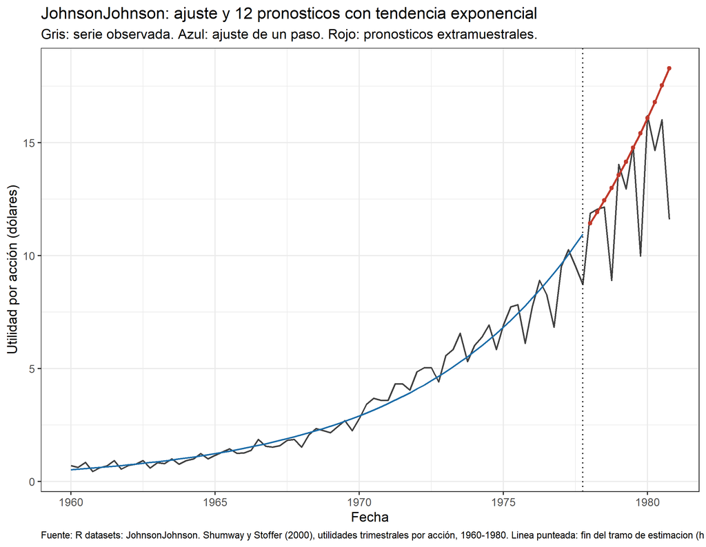

```r
ej7$grafico_final
```

El pronóstico $e^{\hat a+\hat\theta t}$ estima la **mediana** condicional de $Y_t$, no la media, porque la esperanza de una lognormal incluye el término $e^{\sigma^2/2}$. Por eso se usó `corregir_sesgo = TRUE`, que multiplica por $e^{\hat\sigma^2_{\ln}/2}=1.01147$. El límite del método sobre esta serie es la estacionalidad trimestral, que la tendencia no modela y que reaparece como picos en los múltiplos de 4 del correlograma de errores.

**Conclusión.** La tendencia exponencial (MCO sobre logaritmos, con corrección de sesgo $=$ 1.0115) da una tasa de crecimiento $\hat b_1=$ 1.0437 (unos 4.37% trimestral), y sobre el tramo de validación logra MASE = 3.586, mejor que el ingenuo estacional (6.529). Pero es la validación de errores más problemática de los ocho ejemplos: Ljung–Box rechaza con $p=$ 9.84e-16 y Jarque–Bera también, con $p=$ 4.63e-30: los errores no son normales ni independientes. Es exactamente el límite esperado — la tendencia exponencial no modela la estacionalidad trimestral de las utilidades de Johnson & Johnson, que reaparece como estructura en el correlograma de errores.

**Recomendación.** Sirve para caracterizar la tasa de crecimiento estructural de largo plazo de la utilidad por acción, pero no para pronóstico operativo trimestre a trimestre, donde la estacionalidad no capturada genera errores que se repiten cada 4 trimestres. El límite declarado es que la normalidad y la independencia de los errores se rechazan con altísima confianza, así que ningún intervalo de pronóstico basado en este ajuste sería confiable sin antes remover la estacionalidad.

# 9 Ejemplo 8. Holt lineal sobre `WWWusage`

```r
www <- leer_serie(WWWusage,
  fuente = "R datasets: WWWusage. Durbin y Koopman (2001), usuarios conectados a un servidor de internet, un dato por minuto",
  unidad = "Usuarios conectados")
knitr::kable(describir_serie(www, "WWWusage"), digits = 2)
```

| serie | fuente | unidad | frecuencia | inicio | fin | observaciones | media | desv_estandar | minimo | maximo |
| --- | --- | --- | --- | --- | --- | --- | --- | --- | --- | --- |
| WWWusage | R datasets: WWWusage. Durbin y Koopman (2001), usuarios conectados a un servidor de internet, un dato por minuto | Usuarios conectados | 1 | 0001-01-01 | 0100-01-01 | 100 | 137.08 | 40 | 83 | 228 |

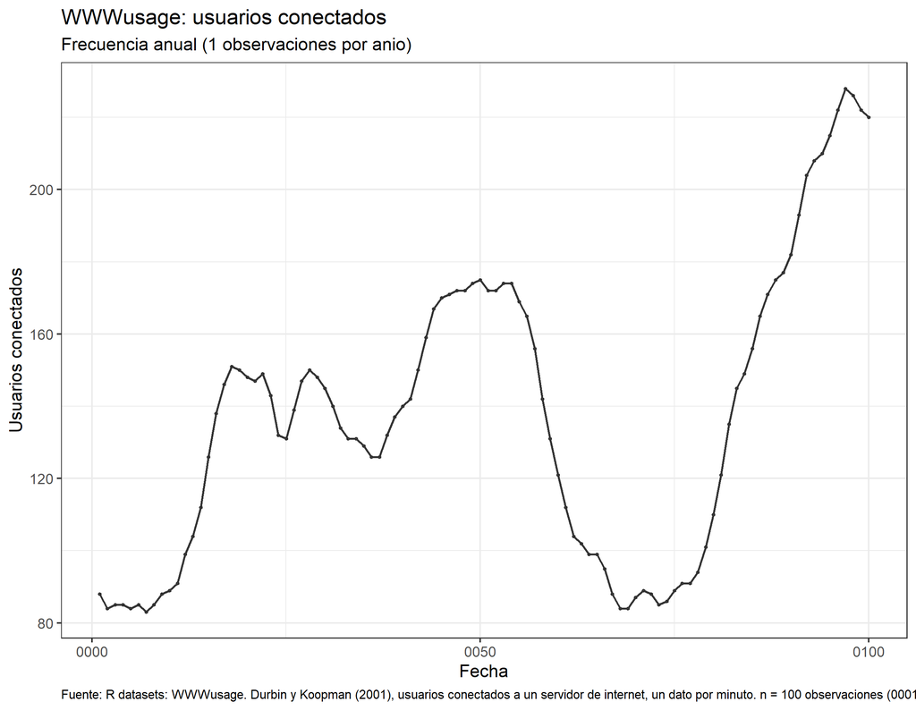

```r
graficar_serie(www, "WWWusage: usuarios conectados")
```

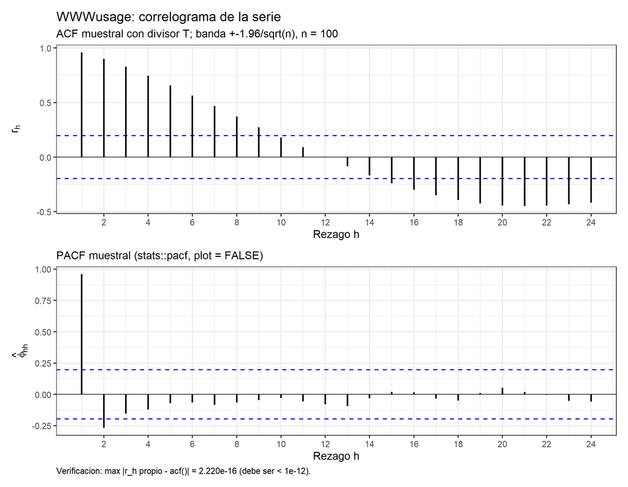

```r
correlograma(www, titulo = "WWWusage: correlograma de la serie")
```

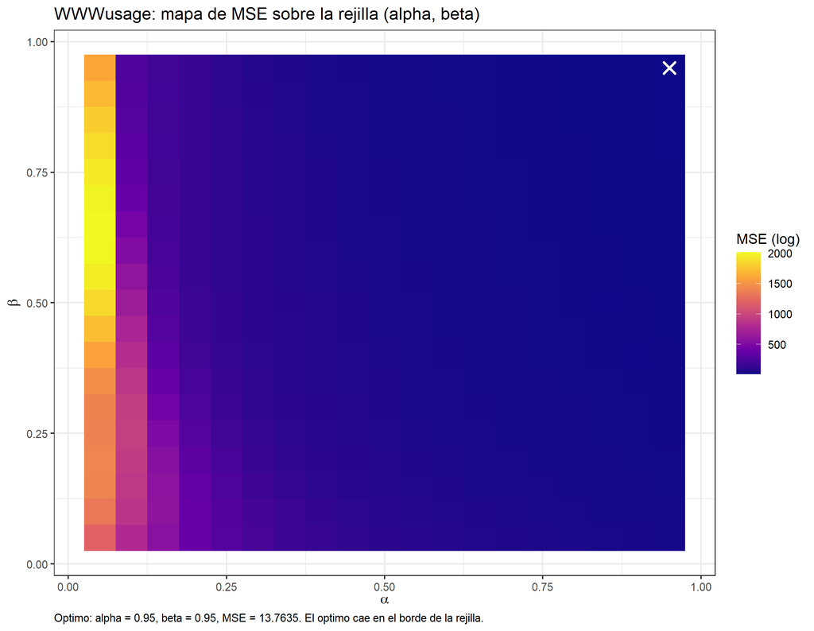

```r
p8 <- particionar(www)
opt8 <- optimizar(p8$estimacion$y, "holt")
graficar_optimizacion(opt8, "WWWusage: mapa de MSE sobre la rejilla (alpha, beta)")
```

```r
a8 <- opt8$optimo$alpha; b8 <- opt8$optimo$beta
ej8 <- protocolo_ejemplo(www, "WWWusage", function(y) ajustar_holt(y, a8, b8),
  sprintf("Holt lineal (alpha = %.2f, beta = %.2f)", a8, b8), p = 2, imprimir = FALSE)
# Verificación de la forma de corrección de error (debe ser ~0)
ej8$ajuste$parametros$dif_max_correccion_error
```

```
[1] 3.730349e-14
```

```r
knitr::kable(dplyr::bind_rows(
  dplyr::mutate(ej8$medidas_dentro, tramo = "estimación"),
  dplyr::mutate(ej8$medidas_fuera,  tramo = "validación"),
  dplyr::mutate(ej8$medidas_referente, tramo = "ingenuo")), digits = 3)
```

| n | MSE | RMSE | MAD | MAPE | MASE | tramo |
| --- | --- | --- | --- | --- | --- | --- |
| 87 | 13.764 | 3.710 | 3.065 | 2.515 | 0.689 | estimación |
| 12 | 94.699 | 9.731 | 8.409 | 3.939 | 1.890 | validación |
| 12 | 1415.417 | 37.622 | 33.917 | 15.689 | 7.625 | ingenuo |

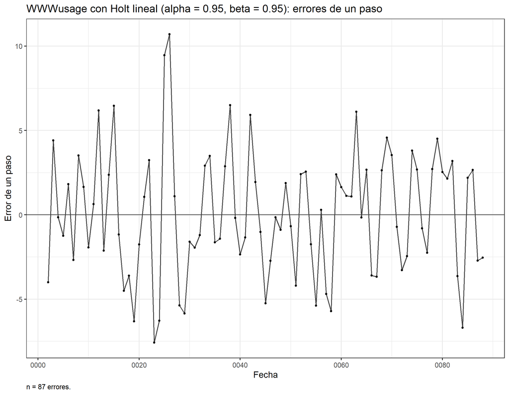

```r
ej8$validacion$grafico_errores
```

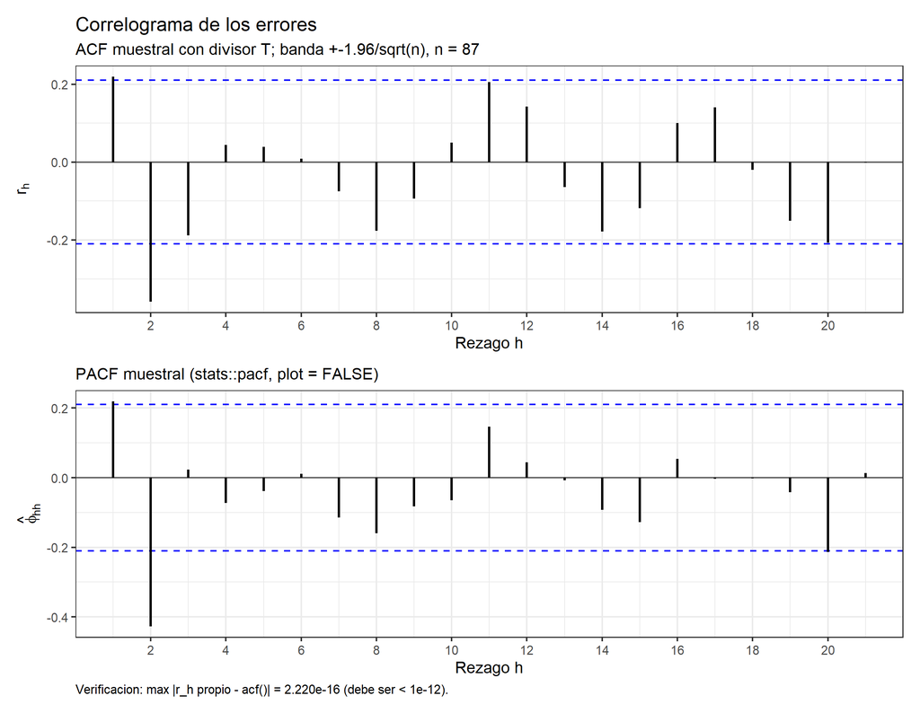

```r
ej8$validacion$correlograma
```

```r
reportar_validacion(ej8)
```

```
=== Prueba sobre la serie WWWusage ===
--- Ljung-Box ---
1. H0: rho_1 = ... = rho_m = 0 (los errores/observaciones no estan autocorrelacionados)
   H1: algun rho_h distinto de cero para h = 1,...,m
2. Estadistico: Q_m = T(T+2) sum_{h=1}^{m} r_h^2/(T-h) ~ chi^2_{m-p}  (gl = 24)
3. Region de rechazo al 5 %: se rechaza H0 si Q_m > chi^2_{0.95, 24} = 36.4150
4. Valor observado = 647.798478 ; valor p = 2.294e-121
5. Decision: se rechaza H0 al 5 %
6. Lectura: Se rechaza H0: hay autocorrelacion (estructura temporal) en la serie WWWusage.

=== Pruebas sobre los errores de un paso: WWWusage con Holt lineal (alpha = 0.95, beta = 0.95) ===
--- t de media cero ---
1. H0: mu_e = 0 (el metodo no esta sesgado)
   H1: mu_e != 0 (el metodo esta sesgado)
2. Estadistico: t = ebar / (s_e/sqrt(n)) ~ t_{n-1}  (gl = 86)
3. Region de rechazo al 5 %: se rechaza H0 si |t| > t_{0.975, 86} = 1.9879
4. Valor observado = 0.130896 ; valor p = 0.8962
5. Decision: no se rechaza H0 al 5 %
6. Lectura: No se rechaza H0: no hay evidencia de sesgo sistematico en los errores de un paso de WWWusage con Holt lineal (alpha = 0.95, beta = 0.95).

--- Ljung-Box ---
1. H0: rho_1 = ... = rho_m = 0 (los errores/observaciones no estan autocorrelacionados)
   H1: algun rho_h distinto de cero para h = 1,...,m
2. Estadistico: Q_m = T(T+2) sum_{h=1}^{m} r_h^2/(T-h) ~ chi^2_{m-p}  (gl = 19)
3. Region de rechazo al 5 %: se rechaza H0 si Q_m > chi^2_{0.95, 19} = 30.1435
4. Valor observado = 46.927200 ; valor p = 0.0003658
5. Decision: se rechaza H0 al 5 %
6. Lectura: Se rechaza H0: hay autocorrelacion (estructura temporal) en los errores de un paso de WWWusage con Holt lineal (alpha = 0.95, beta = 0.95).

--- Jarque-Bera ---
1. H0: los errores provienen de una distribucion normal (A = 0 y K = 3)
   H1: los errores no son normales (A != 0 o K != 3)
2. Estadistico: JB = (N/6)(A^2 + (K-3)^2/4) ~ chi^2_2  (gl = 2)
3. Region de rechazo al 5 %: se rechaza H0 si JB > chi^2_{0.95,2} = 5.9915
4. Valor observado = 0.957243 ; valor p = 0.6196
5. Decision: no se rechaza H0 al 5 %
6. Lectura: No se rechaza H0: la distribucion de los errores de un paso de WWWusage con Holt lineal (alpha = 0.95, beta = 0.95) es compatible con la normal.

--- Durbin-Watson ---
1. H0: rho = 0 (errores no autocorrelacionados de orden 1)
   H1: rho > 0 (autocorrelacion positiva de primer orden)
2. Estadistico: d = sum_t (e_t - e_{t-1})^2 / sum_t e_t^2, con d aprox 2(1 - rho)
3. Region de rechazo al 5 %: se rechaza H0 si d < dL; no se concluye si dL <= d <= dU; no se rechaza si d > dU (cotas de la tabla para T y k regresores)
4. Valor observado = 1.541588 ; valor p = no disponible (ver cotas)
5. Decision: la decision se toma con las cotas dL y dU de la tabla (ver informe)
6. Lectura: d = 1.542, cercano a 2: no sugiere autocorrelacion relevante de primer orden en los errores de un paso de WWWusage con Holt lineal (alpha = 0.95, beta = 0.95); la decision formal se toma con las cotas dL y dU de la tabla.
```

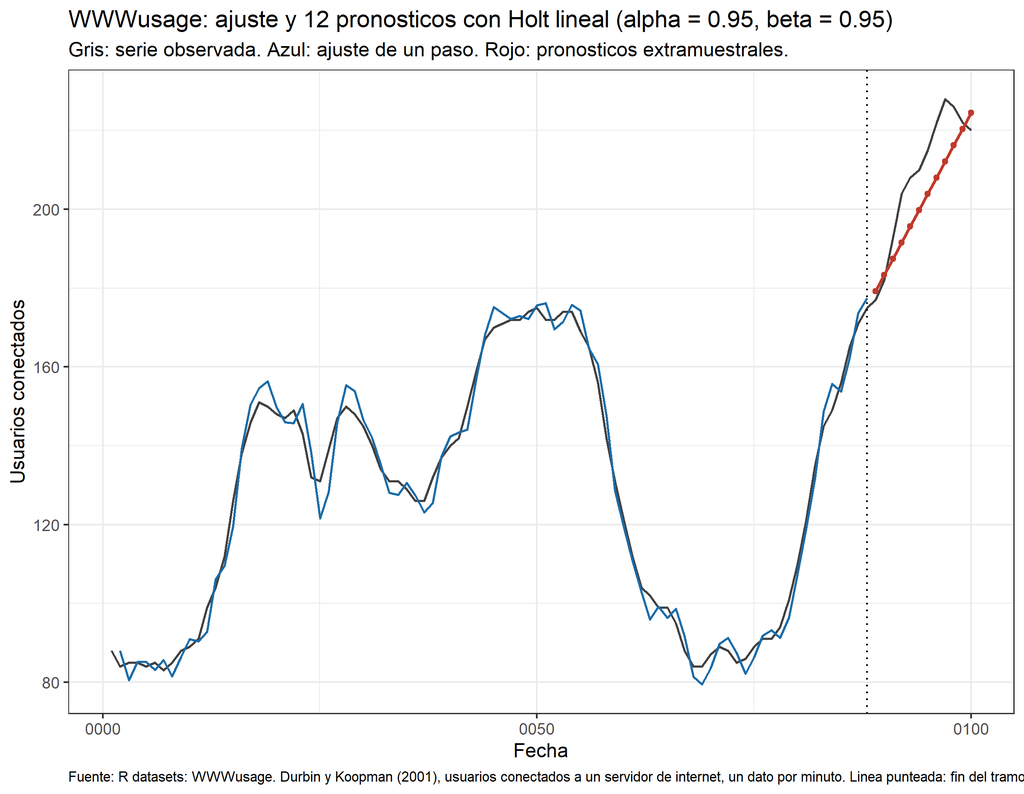

```r
ej8$grafico_final
```

El óptimo de la rejilla es $\alpha=0.95$ y $\beta=0.95$. Cae en el borde de la rejilla: un alpha alto equivale a seguir casi por completo la última observación, señal de que el nivel no es estable.

**Conclusión.** Holt lineal con $\alpha=\beta=$ 0.95 (ambos en el borde superior de la rejilla) logra MASE de validación 1.89, más de cuatro veces mejor que el ingenuo (7.625). Que el óptimo caiga en el borde superior es la lectura clave: el método prefiere seguir casi por completo el último dato y la última pendiente observada, señal de que tanto el nivel como la pendiente de usuarios conectados cambian muy rápido, casi tan rápido como la propia serie. Aun así, Ljung–Box todavía rechaza (Q = 46.9, $p=$ 0.000366): queda estructura residual sin explotar, aunque no hay sesgo ($p=$ 0.896) ni falta de normalidad (Jarque–Bera $p=$ 0.62).

**Recomendación.** Apropiado para pronóstico de muy corto plazo de tráfico de un servidor (minuto a minuto), dado que $\alpha$ y $\beta$ altos privilegian reaccionar rápido a cambios. El límite declarado es justo el óptimo en el borde: el nivel y la pendiente no son estables, así que el pronóstico pierde confiabilidad rápidamente más allá de 2 o 3 pasos; conviene además ampliar la rejilla de búsqueda hasta 0.99 para confirmar que 0.95 sigue siendo el óptimo y no un artefacto del límite superior evaluado.

# 10 Contraejemplo (literal 4e). Media simple sobre `AirPassengers`

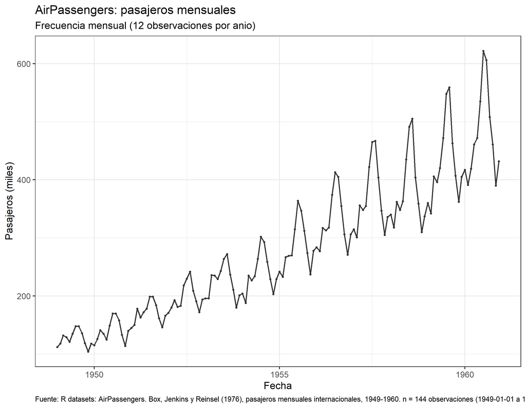

```r
aire <- leer_serie(AirPassengers,
  fuente = "R datasets: AirPassengers. Box, Jenkins y Reinsel (1976), pasajeros mensuales internacionales, 1949-1960",
  unidad = "Pasajeros (miles)")
graficar_serie(aire, "AirPassengers: pasajeros mensuales")
```

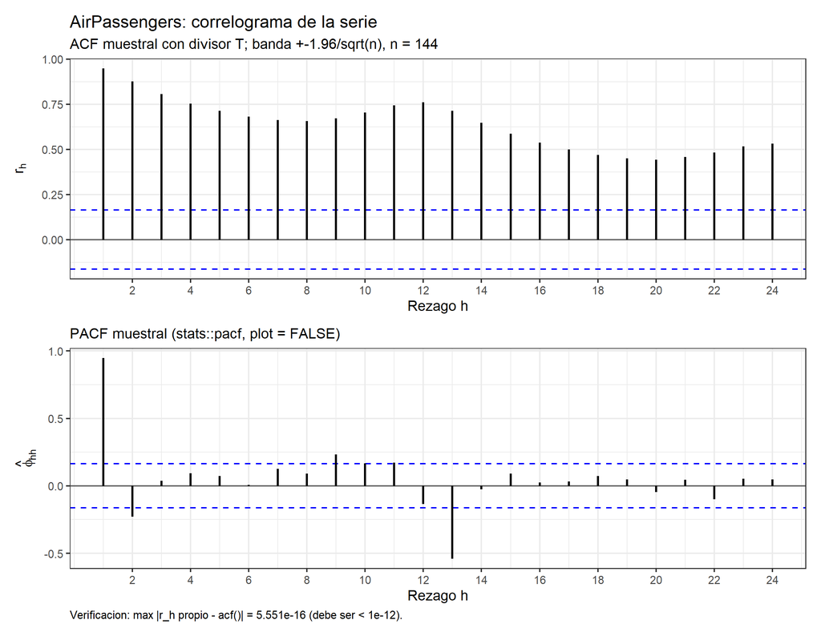

```r
correlograma(aire, titulo = "AirPassengers: correlograma de la serie")
```

```r
ejc <- protocolo_ejemplo(aire, "AirPassengers", ajustar_media,
  "media simple (contraejemplo)", p = 1, estacional = TRUE, imprimir = FALSE)
knitr::kable(dplyr::bind_rows(
  dplyr::mutate(ejc$medidas_dentro, tramo = "estimación"),
  dplyr::mutate(ejc$medidas_fuera,  tramo = "validación"),
  dplyr::mutate(ejc$medidas_referente, tramo = "ingenuo estacional")), digits = 3)
```

| n | MSE | RMSE | MAD | MAPE | MASE | tramo |
| --- | --- | --- | --- | --- | --- | --- |
| 131 | 11493.720 | 107.209 | 83.351 | 26.831 | 2.737 | estimación |
| 12 | 51196.154 | 226.266 | 213.674 | 43.622 | 7.017 | validación |
| 12 | 2571.333 | 50.708 | 47.833 | 9.988 | 1.571 | ingenuo estacional |

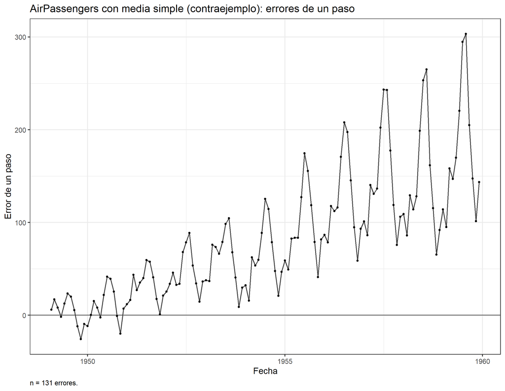

```r
ejc$validacion$grafico_errores
```

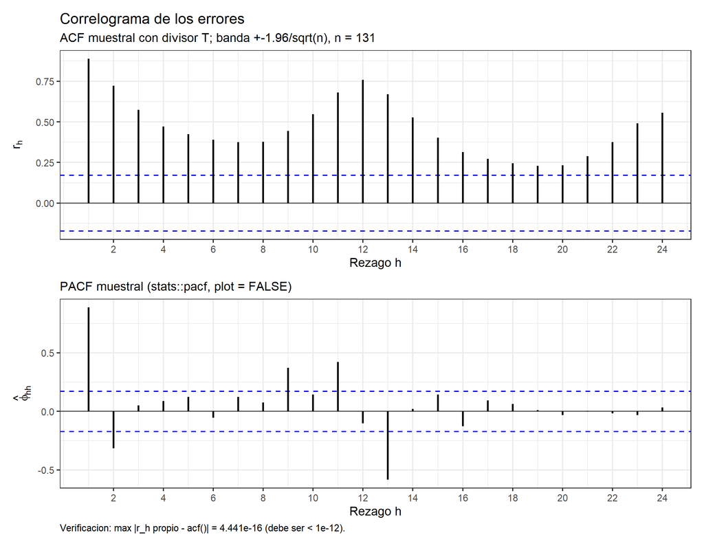

```r
ejc$validacion$correlograma
```

```r
reportar_validacion(ejc, lecturas = list(
  ljung_box = "Los errores de un paso conservan toda la tendencia y toda la estacionalidad de la serie: el método no extrajo la señal."))
```

```
=== Prueba sobre la serie AirPassengers ===
--- Ljung-Box ---
1. H0: rho_1 = ... = rho_m = 0 (los errores/observaciones no estan autocorrelacionados)
   H1: algun rho_h distinto de cero para h = 1,...,m
2. Estadistico: Q_m = T(T+2) sum_{h=1}^{m} r_h^2/(T-h) ~ chi^2_{m-p}  (gl = 24)
3. Region de rechazo al 5 %: se rechaza H0 si Q_m > chi^2_{0.95, 24} = 36.4150
4. Valor observado = 1606.083817 ; valor p =     0
5. Decision: se rechaza H0 al 5 %
6. Lectura: Se rechaza H0: hay autocorrelacion (estructura temporal) en la serie AirPassengers.

=== Pruebas sobre los errores de un paso: AirPassengers con media simple (contraejemplo) ===
--- t de media cero ---
1. H0: mu_e = 0 (el metodo no esta sesgado)
   H1: mu_e != 0 (el metodo esta sesgado)
2. Estadistico: t = ebar / (s_e/sqrt(n)) ~ t_{n-1}  (gl = 130)
3. Region de rechazo al 5 %: se rechaza H0 si |t| > t_{0.975, 130} = 1.9784
4. Valor observado = 13.567857 ; valor p = 1.137e-26
5. Decision: se rechaza H0 al 5 %
6. Lectura: Se rechaza H0: hay evidencia de sesgo sistematico en los errores de un paso de AirPassengers con media simple (contraejemplo); el metodo tiende a subestimar (error medio positivo).

--- Ljung-Box ---
1. H0: rho_1 = ... = rho_m = 0 (los errores/observaciones no estan autocorrelacionados)
   H1: algun rho_h distinto de cero para h = 1,...,m
2. Estadistico: Q_m = T(T+2) sum_{h=1}^{m} r_h^2/(T-h) ~ chi^2_{m-p}  (gl = 23)
3. Region de rechazo al 5 %: se rechaza H0 si Q_m > chi^2_{0.95, 23} = 35.1725
4. Valor observado = 869.615639 ; valor p = 6.347e-169
5. Decision: se rechaza H0 al 5 %
6. Lectura: Los errores de un paso conservan toda la tendencia y toda la estacionalidad de la serie: el método no extrajo la señal.

--- Jarque-Bera ---
1. H0: los errores provienen de una distribucion normal (A = 0 y K = 3)
   H1: los errores no son normales (A != 0 o K != 3)
2. Estadistico: JB = (N/6)(A^2 + (K-3)^2/4) ~ chi^2_2  (gl = 2)
3. Region de rechazo al 5 %: se rechaza H0 si JB > chi^2_{0.95,2} = 5.9915
4. Valor observado = 23.481556 ; valor p = 7.962e-06
5. Decision: se rechaza H0 al 5 %
6. Lectura: Se rechaza H0: la distribucion de los errores de un paso de AirPassengers con media simple (contraejemplo) se aleja de la normal.

--- Durbin-Watson ---
1. H0: rho = 0 (errores no autocorrelacionados de orden 1)
   H1: rho > 0 (autocorrelacion positiva de primer orden)
2. Estadistico: d = sum_t (e_t - e_{t-1})^2 / sum_t e_t^2, con d aprox 2(1 - rho)
3. Region de rechazo al 5 %: se rechaza H0 si d < dL; no se concluye si dL <= d <= dU; no se rechaza si d > dU (cotas de la tabla para T y k regresores)
4. Valor observado = 0.086160 ; valor p = no disponible (ver cotas)
5. Decision: la decision se toma con las cotas dL y dU de la tabla (ver informe)
6. Lectura: d = 0.086, por debajo de 2: sugiere autocorrelacion positiva de primer orden en los errores de un paso de AirPassengers con media simple (contraejemplo); la decision formal se toma con las cotas dL y dU de la tabla.
```

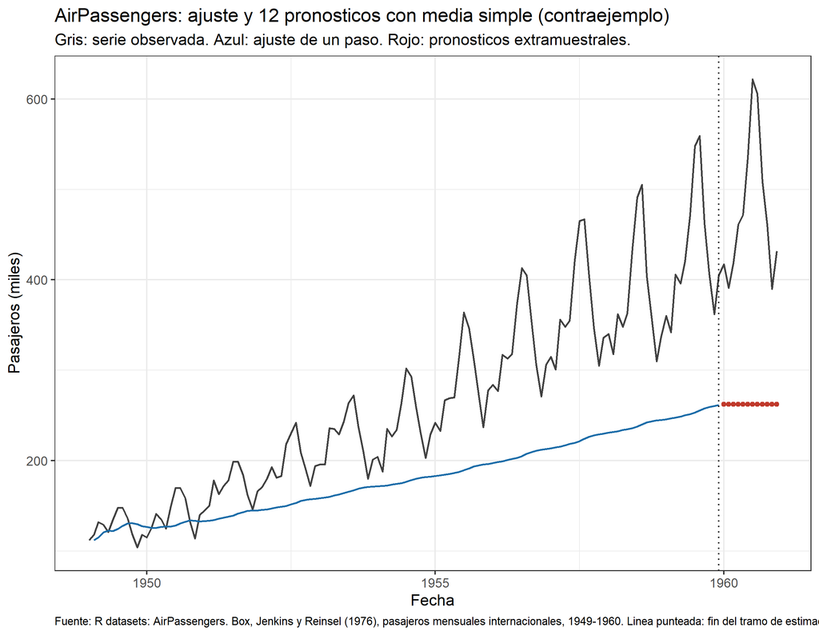

```r
ejc$grafico_final
```

Aquí el supuesto de nivel constante se viola por completo: la serie tiene tendencia creciente y estacionalidad multiplicativa. Se nota en tres cifras. El MASE de validación es 7.02 frente a 1.57 del ingenuo estacional; el estadístico de Ljung–Box sobre los errores vale 869.6 con valor crítico 35.17; y el correlograma de los errores muestra autocorrelaciones positivas que decaen muy lentamente, el patrón de una tendencia no removida. La media simple promedia toda la historia, de modo que el pronóstico se queda anclado muy por debajo del nivel reciente.

# 11 Resumen de resultados

```r
fila <- function(ej, par) tibble::tibble(
  metodo = ej$etiqueta, serie = ej$nombre, parametros = par, h = ej$h,
  MASE_metodo = ej$medidas_fuera$MASE, MASE_referente = ej$medidas_referente$MASE)
knitr::kable(dplyr::bind_rows(
  fila(ej1, "ninguno"), fila(ej2, sprintf("k = %d", k2)),
  fila(ej3, sprintf("alpha = %.2f", a3)), fila(ej4, sprintf("k = %d", k4)),
  fila(ej5, "MCO, 2 coef."), fila(ej6, "MCO, 3 coef."),
  fila(ej7, "MCO en logaritmos"), fila(ej8, sprintf("alpha = %.2f, beta = %.2f", a8, b8)),
  fila(ejc, "contraejemplo")), digits = 3)
```

| metodo | serie | parametros | h | MASE_metodo | MASE_referente |
| --- | --- | --- | --- | --- | --- |
| media simple | Nile | ninguno | 12 | 0.843 | 0.835 |
| media móvil (k = 2) | LakeHuron | k = 2 | 12 | 1.826 | 2.164 |
| SES (alpha = 0.24) | Nile | alpha = 0.24 | 12 | 0.806 | 0.835 |
| doble media móvil (k = 2) | austres | k = 2 | 12 | 1.863 | 6.091 |
| tendencia lineal | austres | MCO, 2 coef. | 12 | 3.974 | 6.091 |
| tendencia cuadrática | airmiles | MCO, 3 coef. | 4 | 1.205 | 4.496 |
| tendencia exponencial | JohnsonJohnson | MCO en logaritmos | 12 | 3.586 | 6.529 |
| Holt lineal (alpha = 0.95, beta = 0.95) | WWWusage | alpha = 0.95, beta = 0.95 | 12 | 1.890 | 7.625 |
| media simple (contraejemplo) | AirPassengers | contraejemplo | 12 | 7.017 | 1.571 |